# Working with Data 2

#### *Similar to the previous lab, be sure to practice this lab SEVERAL times first. Review Quiz 3 (Tuesday, 9/27) will be based on this lab and “Working with Data 1”*

## 1. Import data

Save the dataset and the rmd file at the same folder.

```r
#gss2k is a subset of gss which includes only the observations recorded in years 2000 or later
gss2k <-read.csv("gss2k.csv", stringsAsFactors = TRUE) # 'stringsAsFactors=TRUE' ensures all character vectors in your data frame are formatted as factors
str(gss2k) # make sure all variables, except for age and year, are displayed as factors
```

```
## 'data.frame':    16971 obs. of  13 variables:
##  $ region  : Factor w/ 10 levels "E. NOR. CENTRAL",..: 10 10 10 10 10 10 10 10 10 10 ...
##  $ income  : Factor w/ 14 levels "$1000 TO 2999",..: NA 11 3 5 5 NA 5 4 5 5 ...
##  $ happy   : Factor w/ 4 levels "DK","NOT TOO HAPPY",..: 3 3 3 4 3 3 4 3 3 4 ...
##  $ age     : int  26 48 67 39 25 25 36 44 44 47 ...
##  $ finrela : Factor w/ 6 levels "ABOVE AVERAGE",..: 1 3 3 1 1 NA 2 2 5 1 ...
##  $ marital : Factor w/ 5 levels "DIVORCED","MARRIED",..: 3 1 5 3 1 2 3 1 2 2 ...
##  $ degree  : Factor w/ 5 levels "BACHELOR","GRADUATE",..: 1 3 3 3 4 3 3 4 2 1 ...
##  $ health  : Factor w/ 6 levels "DK","EXCELLENT",..: 2 3 4 NA NA 4 4 4 2 NA ...
##  $ wrkstat : Factor w/ 8 levels "KEEPING HOUSE",..: 7 7 1 7 7 7 7 7 7 7 ...
##  $ partyid : Factor w/ 8 levels "IND NEAR DEM",..: 2 5 3 2 4 7 5 1 4 8 ...
##  $ polviews: Factor w/ 8 levels "CONSERVATIVE",..: 7 1 1 7 8 8 6 5 8 4 ...
##  $ sex     : Factor w/ 2 levels "FEMALE","MALE": 2 1 1 1 1 1 2 1 2 2 ...
##  $ year    : int  2000 2000 2000 2000 2000 2000 2000 2000 2000 2000 ...
```

```r
table(gss2k$year) #first row shows years, second row shows frequency for each year
```

```
##
## 2000 2002 2004 2006 2008 2010
## 2817 2765 2812 4510 2023 2044
```

## 2. Frequency/Relative Frequency Tables using *table()* and *prop.table()*: useful for factors

```r
happy_tab <- table(gss2k$happy) # displays how many respondents belong to each level of happiness
happy_tab
```

```
##
##            DK NOT TOO HAPPY  PRETTY HAPPY    VERY HAPPY
##             2          1666          7085          3772
```

```r
max(happy_tab) # What's the highest frequency?
```

```
## [1] 7085
```

```r
which.max(happy_tab) # Which level of "happy" gives you the highest frequency?
```

```
## PRETTY HAPPY
##            3
```

```r
prop.table(happy_tab) # Instead of frequency, displays proportions for each level of happiness
```

```
##
##            DK NOT TOO HAPPY  PRETTY HAPPY    VERY HAPPY
##  0.0001596806  0.1330139721  0.5656686627  0.3011576846
```

```r
prop.table(happy_tab)*100 # Displays percentages instead
```

```
##
##            DK NOT TOO HAPPY  PRETTY HAPPY    VERY HAPPY
##    0.01596806   13.30139721   56.56686627   30.11576846
```

```r
# Making contingency tables using TWO factors
sex_by_happy_tab <- table(gss2k$sex, gss2k$happy) # organizes the frequency of males and females by each level of "happy"
sex_by_happy_tab
```

```
##
##            DK NOT TOO HAPPY PRETTY HAPPY VERY HAPPY
##   FEMALE    2           925         3892       2112
##   MALE      0           741         3193       1660
```

```r
# Contingency table displaying proportions out of total
prop.table(sex_by_happy_tab) #the sum of all proportions is 1
```

```
##
##                    DK NOT TOO HAPPY PRETTY HAPPY   VERY HAPPY
##   FEMALE 0.0001596806  0.0738522954 0.3107385230 0.1686227545
##   MALE   0.0000000000  0.0591616766 0.2549301397 0.1325349301
```

```r
prop.table(sex_by_happy_tab, margin=1) #displays proportions out of each row as the total
```

```
##
##                    DK NOT TOO HAPPY PRETTY HAPPY   VERY HAPPY
##   FEMALE 0.0002885586  0.1334583754 0.5615351320 0.3047179339
##   MALE   0.0000000000  0.1324633536 0.5707901323 0.2967465141
```

```r
prop.table(sex_by_happy_tab, margin=2) #displays proportions out of each column as the total
```

```
##
##                 DK NOT TOO HAPPY PRETTY HAPPY VERY HAPPY
##   FEMALE 1.0000000     0.5552221    0.5493296  0.5599152
##   MALE   0.0000000     0.4447779    0.4506704  0.4400848
```

## 3. Summary tables usig *tapply()*: useful for summarizing numeric vector by factor

```r
?tapply #learn about the function by reading the help document

#tapply(vector1, vector2, function to apply)
med_age_sex <- tapply(gss2k$age, gss2k$sex, median, na.rm=TRUE) # median age for males and females
med_age_sex
```

```
## FEMALE   MALE
##     45     45
```

```r
avg_age_year <- tapply(gss2k$age, gss2k$year, mean, na.rm=TRUE) # average age of respondents for each year
avg_age_year
```

```
##     2000     2002     2004     2006     2008     2010
## 46.02243 46.28281 45.96468 47.14159 47.70840 48.04207
```

```r
#print maximum and minimum average ages from age_year table
max(avg_age_year)
```

```
## [1] 48.04207
```

```r
min(avg_age_year)
```

```
## [1] 45.96468
```

```r
#print which year had the maximum or minimum average age
which.max(avg_age_year) #first row shows the name of the level, second row shows the index of the level in the table (i.e., year 2010 is the 6th level in the age_year table)
```

```
## 2010
##    6
```

```r
which.min(avg_age_year)
```

```
## 2004
##    3
```

## 4. Converting between numeric vector and factor

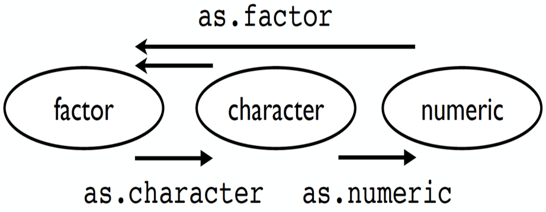

### A. Convert a numeric vector to a factor: Convert “age” (numeric) into “age_factor”.

Rather than modifying the existing variable (age), create a new variable (age_factor) by applying the conditions to the original variable (age).

```r
is.numeric(gss2k$age)
```

```
## [1] TRUE
```

```r
summary(gss2k$age) # displays numeric summary because "age" is a numeric vector
```

```
##    Min. 1st Qu.  Median    Mean 3rd Qu.    Max.    NA's
##    18.0    33.0    45.0    46.8    59.0    99.0      59
```

```r
table(gss2k$age) # prints frequency table for "age": shows how many respondents are for each age
```

```
##
##  18  19  20  21  22  23  24  25  26  27  28  29  30  31  32  33  34  35  36  37
##  73 204 206 223 239 301 286 317 324 312 315 297 329 323 343 339 345 342 355 344
##  38  39  40  41  42  43  44  45  46  47  48  49  50  51  52  53  54  55  56  57
## 342 321 376 340 327 365 364 328 354 356 354 335 344 305 326 304 301 266 295 247
##  58  59  60  61  62  63  64  65  66  67  68  69  70  71  72  73  74  75  76  77
## 241 245 265 232 235 215 184 181 177 207 160 158 164 149 154 110 138 142 130 105
##  78  79  80  81  82  83  84  85  86  87  88  89  99
## 107  98 101  93  87  82  74  64  55  36  39 114   3
```

```r
# Make a quick factor using as.factor()
gss2k$age_factor_quick <- as.factor(gss2k$age) # this quickly converts "age" (numeric) into a factor by changing each age into a level with no issue, but...
is.factor(gss2k$age_factor_quick)
```

```
## [1] TRUE
```

```r
levels(gss2k$age_factor_quick) # this isn't going to help because we have too many levels. Let's try using fewer levels.
```

```
##  [1] "18" "19" "20" "21" "22" "23" "24" "25" "26" "27" "28" "29" "30" "31" "32"
## [16] "33" "34" "35" "36" "37" "38" "39" "40" "41" "42" "43" "44" "45" "46" "47"
## [31] "48" "49" "50" "51" "52" "53" "54" "55" "56" "57" "58" "59" "60" "61" "62"
## [46] "63" "64" "65" "66" "67" "68" "69" "70" "71" "72" "73" "74" "75" "76" "77"
## [61] "78" "79" "80" "81" "82" "83" "84" "85" "86" "87" "88" "89" "99"
```

```r
# create a new factor with three levels in order
## new vector<-factor(vector, levels=c("level1","level2","level3")), ordered=TRUE)
gss2k$age_factor<-factor(gss2k$age, levels=c("young adult","middle-aged","older adult"), ordered=TRUE)
is.factor(gss2k$age_factor) #confirm that "age_factor" is a factor
```

```
## [1] TRUE
```

```r
levels(gss2k$age_factor) #shows the levels we created for "age_factor"
```

```
## [1] "young adult" "middle-aged" "older adult"
```

```r
#printing the first 100 values of gss2k$age_factor to save space (rather than printing all values)
gss2k$age_factor[1:100] #note that this variable has only NAs, which means we still need to tell R conditions for each level of "age_factor"
```

```
##   [1] <NA> <NA> <NA> <NA> <NA> <NA> <NA> <NA> <NA> <NA> <NA> <NA> <NA> <NA> <NA>
##  [16] <NA> <NA> <NA> <NA> <NA> <NA> <NA> <NA> <NA> <NA> <NA> <NA> <NA> <NA> <NA>
##  [31] <NA> <NA> <NA> <NA> <NA> <NA> <NA> <NA> <NA> <NA> <NA> <NA> <NA> <NA> <NA>
##  [46] <NA> <NA> <NA> <NA> <NA> <NA> <NA> <NA> <NA> <NA> <NA> <NA> <NA> <NA> <NA>
##  [61] <NA> <NA> <NA> <NA> <NA> <NA> <NA> <NA> <NA> <NA> <NA> <NA> <NA> <NA> <NA>
##  [76] <NA> <NA> <NA> <NA> <NA> <NA> <NA> <NA> <NA> <NA> <NA> <NA> <NA> <NA> <NA>
##  [91] <NA> <NA> <NA> <NA> <NA> <NA> <NA> <NA> <NA> <NA>
## Levels: young adult < middle-aged < older adult
```

```r
#we are using the values of "age" variable to determine which level of "age_factor" each respondent belongs to.
gss2k$age_factor[gss2k$age>=18 & gss2k$age<=35]<-"young adult"
gss2k$age_factor[1:100]
```

```
##   [1] young adult <NA>        <NA>        <NA>        young adult young adult
##   [7] <NA>        <NA>        <NA>        <NA>        <NA>        <NA>
##  [13] <NA>        <NA>        <NA>        <NA>        <NA>        <NA>
##  [19] <NA>        <NA>        <NA>        <NA>        young adult <NA>
##  [25] <NA>        <NA>        <NA>        <NA>        <NA>        <NA>
##  [31] <NA>        young adult <NA>        <NA>        young adult young adult
##  [37] <NA>        <NA>        young adult <NA>        young adult <NA>
##  [43] <NA>        <NA>        young adult <NA>        <NA>        <NA>
##  [49] <NA>        <NA>        young adult <NA>        <NA>        <NA>
##  [55] young adult <NA>        <NA>        <NA>        young adult young adult
##  [61] young adult young adult young adult <NA>        young adult <NA>
##  [67] <NA>        young adult young adult <NA>        <NA>        <NA>
##  [73] <NA>        <NA>        <NA>        young adult <NA>        <NA>
##  [79] young adult young adult <NA>        <NA>        <NA>        <NA>
##  [85] <NA>        <NA>        young adult <NA>        young adult <NA>
##  [91] <NA>        <NA>        <NA>        young adult <NA>        young adult
##  [97] <NA>        <NA>        <NA>        <NA>
## Levels: young adult < middle-aged < older adult
```

```r
gss2k$age_factor[gss2k$age>35 & gss2k$age<=55]<-"middle-aged"
gss2k$age_factor[1:100]
```

```
##   [1] young adult middle-aged <NA>        middle-aged young adult young adult
##   [7] middle-aged middle-aged middle-aged middle-aged middle-aged middle-aged
##  [13] middle-aged middle-aged middle-aged middle-aged <NA>        middle-aged
##  [19] middle-aged middle-aged middle-aged middle-aged young adult middle-aged
##  [25] <NA>        <NA>        <NA>        <NA>        <NA>        <NA>
##  [31] <NA>        young adult middle-aged middle-aged young adult young adult
##  [37] middle-aged middle-aged young adult <NA>        young adult middle-aged
##  [43] middle-aged middle-aged young adult middle-aged <NA>        middle-aged
##  [49] <NA>        <NA>        young adult <NA>        <NA>        middle-aged
##  [55] young adult middle-aged middle-aged middle-aged young adult young adult
##  [61] young adult young adult young adult <NA>        young adult middle-aged
##  [67] <NA>        young adult young adult <NA>        <NA>        <NA>
##  [73] <NA>        <NA>        <NA>        young adult <NA>        middle-aged
##  [79] young adult young adult middle-aged middle-aged <NA>        middle-aged
##  [85] middle-aged <NA>        young adult middle-aged young adult <NA>
##  [91] <NA>        middle-aged middle-aged young adult middle-aged young adult
##  [97] middle-aged middle-aged <NA>        middle-aged
## Levels: young adult < middle-aged < older adult
```

```r
gss2k$age_factor[gss2k$age>55]<-"older adult"
gss2k$age_factor[1:100]
```

```
##   [1] young adult middle-aged older adult middle-aged young adult young adult
##   [7] middle-aged middle-aged middle-aged middle-aged middle-aged middle-aged
##  [13] middle-aged middle-aged middle-aged middle-aged older adult middle-aged
##  [19] middle-aged middle-aged middle-aged middle-aged young adult middle-aged
##  [25] older adult older adult older adult older adult older adult older adult
##  [31] older adult young adult middle-aged middle-aged young adult young adult
##  [37] middle-aged middle-aged young adult older adult young adult middle-aged
##  [43] middle-aged middle-aged young adult middle-aged older adult middle-aged
##  [49] older adult older adult young adult older adult older adult middle-aged
##  [55] young adult middle-aged middle-aged middle-aged young adult young adult
##  [61] young adult young adult young adult older adult young adult middle-aged
##  [67] older adult young adult young adult older adult older adult older adult
##  [73] older adult older adult older adult young adult older adult middle-aged
##  [79] young adult young adult middle-aged middle-aged older adult middle-aged
##  [85] middle-aged older adult young adult middle-aged young adult older adult
##  [91] older adult middle-aged middle-aged young adult middle-aged young adult
##  [97] middle-aged middle-aged older adult middle-aged
## Levels: young adult < middle-aged < older adult
```

```r
summary(gss2k$age_factor) #confirm that the 59 NAs from "age" still remain as NAs for "age_factor"
```

```
## young adult middle-aged older adult        NA's
##        5118        6707        5087          59
```

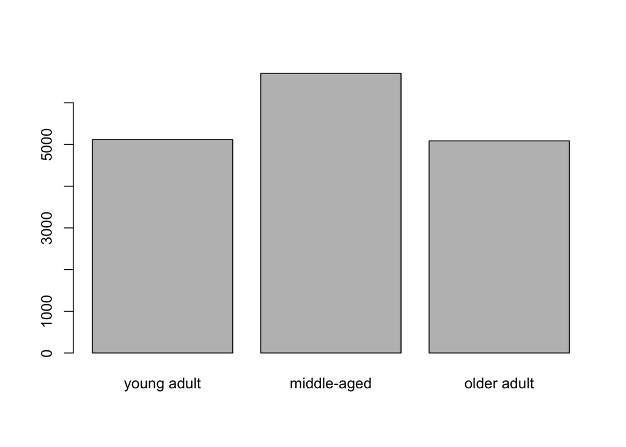

```r
barplot(table(gss2k$age_factor))
```

### B. Convert factor to numeric vector: Convert “age_factor” back into another numeric vector, “age1”

#### STEP 1: create a factor with new levels

```r
gss2k$age1<-factor(gss2k$age, levels=c("26.5","45.5","77.5")) # using midpoint age of each level of "age_factor" as new levels of "age1"

gss2k$age1[gss2k$age_factor=="young adult"]<-"26.5"
gss2k$age1[1:100]
```

```
##   [1] 26.5 <NA> <NA> <NA> 26.5 26.5 <NA> <NA> <NA> <NA> <NA> <NA> <NA> <NA> <NA>
##  [16] <NA> <NA> <NA> <NA> <NA> <NA> <NA> 26.5 <NA> <NA> <NA> <NA> <NA> <NA> <NA>
##  [31] <NA> 26.5 <NA> <NA> 26.5 26.5 <NA> <NA> 26.5 <NA> 26.5 <NA> <NA> <NA> 26.5
##  [46] <NA> <NA> <NA> <NA> <NA> 26.5 <NA> <NA> <NA> 26.5 <NA> <NA> <NA> 26.5 26.5
##  [61] 26.5 26.5 26.5 <NA> 26.5 <NA> <NA> 26.5 26.5 <NA> <NA> <NA> <NA> <NA> <NA>
##  [76] 26.5 <NA> <NA> 26.5 26.5 <NA> <NA> <NA> <NA> <NA> <NA> 26.5 <NA> 26.5 <NA>
##  [91] <NA> <NA> <NA> 26.5 <NA> 26.5 <NA> <NA> <NA> <NA>
## Levels: 26.5 45.5 77.5
```

```r
gss2k$age1[gss2k$age_factor=="middle-aged"]<-"45.5"
gss2k$age1[1:100]
```

```
##   [1] 26.5 45.5 <NA> 45.5 26.5 26.5 45.5 45.5 45.5 45.5 45.5 45.5 45.5 45.5 45.5
##  [16] 45.5 <NA> 45.5 45.5 45.5 45.5 45.5 26.5 45.5 <NA> <NA> <NA> <NA> <NA> <NA>
##  [31] <NA> 26.5 45.5 45.5 26.5 26.5 45.5 45.5 26.5 <NA> 26.5 45.5 45.5 45.5 26.5
##  [46] 45.5 <NA> 45.5 <NA> <NA> 26.5 <NA> <NA> 45.5 26.5 45.5 45.5 45.5 26.5 26.5
##  [61] 26.5 26.5 26.5 <NA> 26.5 45.5 <NA> 26.5 26.5 <NA> <NA> <NA> <NA> <NA> <NA>
##  [76] 26.5 <NA> 45.5 26.5 26.5 45.5 45.5 <NA> 45.5 45.5 <NA> 26.5 45.5 26.5 <NA>
##  [91] <NA> 45.5 45.5 26.5 45.5 26.5 45.5 45.5 <NA> 45.5
## Levels: 26.5 45.5 77.5
```

```r
gss2k$age1[gss2k$age_factor=="older adult"]<-"77.5"
gss2k$age1[1:100]
```

```
##   [1] 26.5 45.5 77.5 45.5 26.5 26.5 45.5 45.5 45.5 45.5 45.5 45.5 45.5 45.5 45.5
##  [16] 45.5 77.5 45.5 45.5 45.5 45.5 45.5 26.5 45.5 77.5 77.5 77.5 77.5 77.5 77.5
##  [31] 77.5 26.5 45.5 45.5 26.5 26.5 45.5 45.5 26.5 77.5 26.5 45.5 45.5 45.5 26.5
##  [46] 45.5 77.5 45.5 77.5 77.5 26.5 77.5 77.5 45.5 26.5 45.5 45.5 45.5 26.5 26.5
##  [61] 26.5 26.5 26.5 77.5 26.5 45.5 77.5 26.5 26.5 77.5 77.5 77.5 77.5 77.5 77.5
##  [76] 26.5 77.5 45.5 26.5 26.5 45.5 45.5 77.5 45.5 45.5 77.5 26.5 45.5 26.5 77.5
##  [91] 77.5 45.5 45.5 26.5 45.5 26.5 45.5 45.5 77.5 45.5
## Levels: 26.5 45.5 77.5
```

```r
#"age1" is still a factor using midpoint ages as new levels. We still need to convert it to a numeric vector
is.factor(gss2k$age1)
```

```
## [1] TRUE
```

```r
levels(gss2k$age1)
```

```
## [1] "26.5" "45.5" "77.5"
```

#### **WRONG** STEP 2: convert “age1” into a numeric vector “age2” directly

```r
#converting "age1" directly into a numeric vector using as.numeric() does NOT work.
gss2k$age2 <- as.numeric(gss2k$age1)
is.numeric(gss2k$age2) # "age1" is numeric, but...
```

```
## [1] TRUE
```

```r
gss2k$age2[1:100] # "age2" shows the level number instead of the actual levels
```

```
##   [1] 1 2 3 2 1 1 2 2 2 2 2 2 2 2 2 2 3 2 2 2 2 2 1 2 3 3 3 3 3 3 3 1 2 2 1 1 2
##  [38] 2 1 3 1 2 2 2 1 2 3 2 3 3 1 3 3 2 1 2 2 2 1 1 1 1 1 3 1 2 3 1 1 3 3 3 3 3
##  [75] 3 1 3 2 1 1 2 2 3 2 2 3 1 2 1 3 3 2 2 1 2 1 2 2 3 2
```

#### **CORRECT** STEP 2: Before converting it into a numeric vector, first convert the factor to a character. Then cast it to a numeric (if not, you only convert the level number to a numeric)

```r
gss2k$age1<-as.numeric(as.character(gss2k$age1))
gss2k$age1[1:100] ## printing only the first 100 values of "age1" to save space
```

```
##   [1] 26.5 45.5 77.5 45.5 26.5 26.5 45.5 45.5 45.5 45.5 45.5 45.5 45.5 45.5 45.5
##  [16] 45.5 77.5 45.5 45.5 45.5 45.5 45.5 26.5 45.5 77.5 77.5 77.5 77.5 77.5 77.5
##  [31] 77.5 26.5 45.5 45.5 26.5 26.5 45.5 45.5 26.5 77.5 26.5 45.5 45.5 45.5 26.5
##  [46] 45.5 77.5 45.5 77.5 77.5 26.5 77.5 77.5 45.5 26.5 45.5 45.5 45.5 26.5 26.5
##  [61] 26.5 26.5 26.5 77.5 26.5 45.5 77.5 26.5 26.5 77.5 77.5 77.5 77.5 77.5 77.5
##  [76] 26.5 77.5 45.5 26.5 26.5 45.5 45.5 77.5 45.5 45.5 77.5 26.5 45.5 26.5 77.5
##  [91] 77.5 45.5 45.5 26.5 45.5 26.5 45.5 45.5 77.5 45.5
```

```r
is.numeric(gss2k$age1) #note that "age1" is successfully converted into a numeric vector.
```

```
## [1] TRUE
```

```r
#let's check the summary for a numeric vector "age1"
summary(gss2k$age1) #note that this looks different from summary of "age". Why?
```

```
##    Min. 1st Qu.  Median    Mean 3rd Qu.    Max.    NA's
##   26.50   26.50   45.50   49.38   77.50   77.50      59
```

```r
summary(gss2k$age)
```

```
##    Min. 1st Qu.  Median    Mean 3rd Qu.    Max.    NA's
##    18.0    33.0    45.0    46.8    59.0    99.0      59
```

### C. **Try this ONLY AFTER completing 4A & 4B**: An alternative way to convert factor to numeric vector quickly: Convert “age_factor” back into another numeric vector, “age_num”

```r
levels(gss2k$age_factor)
```

```
## [1] "young adult" "middle-aged" "older adult"
```

```r
gss2k$age_num <- gss2k$age_factor #making a copy of "age_factor" to create "age_num"
levels(gss2k$age_num) # confirm that "age_num" still has the same levels of "age_factor"
```

```
## [1] "young adult" "middle-aged" "older adult"
```

```r
levels(gss2k$age_num) <- c(26.5, 45.5, 77.5) # using midpoint age for each level WITHOUT " " will allow us to use numbers as levels of "age_num"
gss2k$age_num[1:100]
```

```
##   [1] 26.5 45.5 77.5 45.5 26.5 26.5 45.5 45.5 45.5 45.5 45.5 45.5 45.5 45.5 45.5
##  [16] 45.5 77.5 45.5 45.5 45.5 45.5 45.5 26.5 45.5 77.5 77.5 77.5 77.5 77.5 77.5
##  [31] 77.5 26.5 45.5 45.5 26.5 26.5 45.5 45.5 26.5 77.5 26.5 45.5 45.5 45.5 26.5
##  [46] 45.5 77.5 45.5 77.5 77.5 26.5 77.5 77.5 45.5 26.5 45.5 45.5 45.5 26.5 26.5
##  [61] 26.5 26.5 26.5 77.5 26.5 45.5 77.5 26.5 26.5 77.5 77.5 77.5 77.5 77.5 77.5
##  [76] 26.5 77.5 45.5 26.5 26.5 45.5 45.5 77.5 45.5 45.5 77.5 26.5 45.5 26.5 77.5
##  [91] 77.5 45.5 45.5 26.5 45.5 26.5 45.5 45.5 77.5 45.5
## Levels: 26.5 < 45.5 < 77.5
```

```r
is.numeric(gss2k$age_num) # "age_num" is still a factor
```

```
## [1] FALSE
```

```r
gss2k$age_num <- as.numeric(as.character(gss2k$age_num))
is.numeric(gss2k$age_num) # "age_num" is now a numeric vector
```

```
## [1] TRUE
```

```r
summary(gss2k$age_num) # printing summary of "age_num"
```

```
##    Min. 1st Qu.  Median    Mean 3rd Qu.    Max.    NA's
##   26.50   26.50   45.50   49.38   77.50   77.50      59
```

```r
summary(gss2k$age1) #printing summary of "age1". Compare it with the summary of "age_num"
```

```
##    Min. 1st Qu.  Median    Mean 3rd Qu.    Max.    NA's
##   26.50   26.50   45.50   49.38   77.50   77.50      59
```